# 스포츠과학원 재직자교육 - R을 활용한 데이터 분석

## 시각화 분석

### 두 변수의 관계

이번 분석에서는 상대악력과 윗뭄말아올리기(`ITEM_F009`)와 관계를 시각적으로 분석해 보자.

```r
df_grip <- df_data %>%
  mutate( grip_rel = pmax(ITEM_F007, ITEM_F008, na.rm = TRUE) / ITEM_F002 * 100 ) %>%
  rename(curl_up = ITEM_F009) %>%
  select( TEST_YEAR, TEST_SEX, TEST_AGE, curl_up, grip_rel) %>%
  na.omit()

head(df_grip, 20) %>%
  flextable() %>%
  autofit()
```

| TEST_YEAR | TEST_SEX | TEST_AGE | curl_up | grip_rel |
| --- | --- | --- | --- | --- |
| 2024 | 여성 | 17 | 21 | 44.56036 |
| 2021 | 남성 | 17 | 23 | 72.81192 |
| 2022 | 남성 | 16 | 46 | 67.15818 |
| 2020 | 남성 | 17 | 22 | 58.27160 |
| 2024 | 여성 | 17 | 8 | 49.42529 |
| 2022 | 남성 | 13 | 18 | 40.28269 |
| 2022 | 여성 | 15 | 33 | 45.55556 |
| 2024 | 남성 | 18 | 31 | 62.20472 |
| 2023 | 남성 | 15 | 51 | 65.64417 |
| 2022 | 남성 | 15 | 20 | 41.06335 |
| 2023 | 여성 | 15 | 43 | 45.74830 |
| 2021 | 남성 | 16 | 19 | 46.18609 |
| 2021 | 남성 | 16 | 15 | 45.85192 |
| 2021 | 남성 | 17 | 18 | 60.51051 |
| 2023 | 여성 | 18 | 23 | 51.03306 |
| 2024 | 여성 | 13 | 25 | 64.07186 |
| 2022 | 남성 | 17 | 13 | 40.58577 |
| 2023 | 남성 | 15 | 73 | 67.92453 |
| 2022 | 남성 | 16 | 22 | 62.57521 |
| 2024 | 남성 | 18 | 51 | 52.00000 |

이제 상대악력과 윗몸말아올리기의 관계를 `ggplot` 함수를 이용하여 산점도로 나타내 보자.

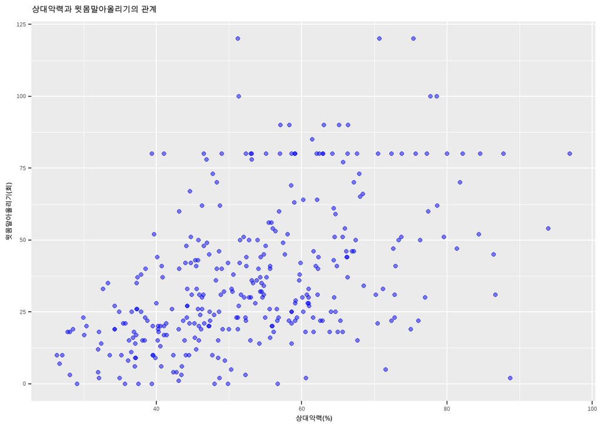

```r
ggplot( df_grip, aes(x = grip_rel, y = curl_up)) +
  geom_point( alpha = 0.5, color = "blue") +
  labs( title = "상대악력과 윗몸말아올리기의 관계",
        x = "상대악력(%)",
        y = "윗몸말아올리기(회)")
```

두 변수의 관계는 성별로 다를 수 있으므로 남자와 여자의 자료를 색깔로 구별하여 산점도를 그려보자.

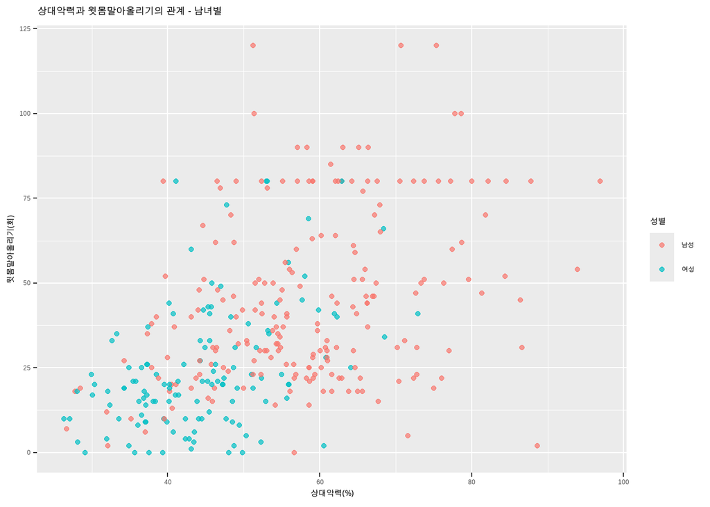

```r
ggplot( df_grip, aes(x = grip_rel, y = curl_up, color = TEST_SEX)) +
  geom_point( alpha = 0.7) +
  labs( title = "상대악력과 윗몸말아올리기의 관계 - 남녀별",
        x = "상대악력(%)",
        y = "윗몸말아올리기(회)",
        color = "성별")
```

남녀벌로 다른 그림으로 분리하여 다음과 같이 두 개의 산점도로 나타낼 수 있다.

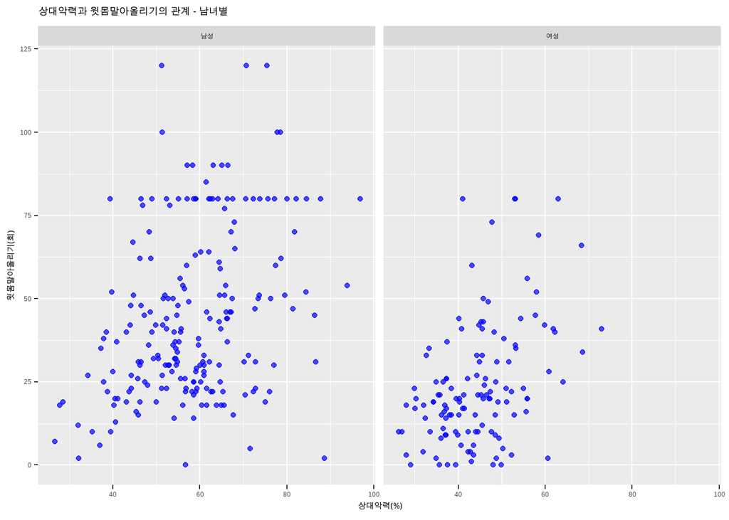

```r
ggplot( df_grip, aes(x = grip_rel, y = curl_up)) +
  geom_point( alpha = 0.7, color = "blue") +
  labs( title = "상대악력과 윗몸말아올리기의 관계 - 남녀별",
        x = "상대악력(%)",
        y = "윗몸말아올리기(회)") +
  facet_wrap( ~ TEST_SEX)
```

### 분포의 비교

다음으로 연도별로 BMI(`ITEM_F018`) 분포를 비교해 보자. 이를 위해 `ggplot` 함수를 이용하여 각 연도마다 상자그림으로 분포를 나타낼 수 있다. 먼저 청소년 남자들의 분포를 비교해 보자.

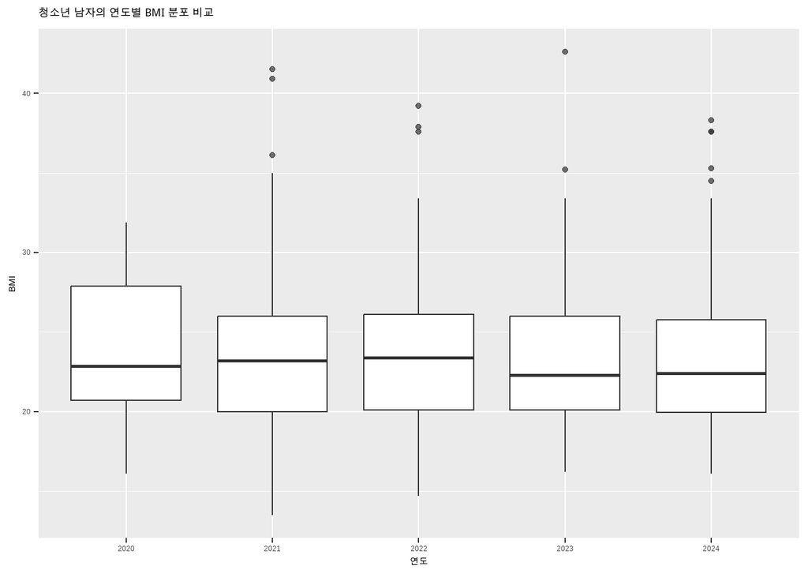

```r
df_bmi_1 <- df_data %>%
  filter( TEST_SEX == "남성" &  AGE_GBN == "청소년") %>%
  select( TEST_YEAR, ITEM_F018) %>%
  rename( bmi = ITEM_F018, year = TEST_YEAR)

ggplot( df_bmi_1, aes(x = year, y = bmi )) +
  geom_boxplot(outlier.alpha = 0.7) +
  labs( title = "청소년 남자의 연도별 BMI 분포 비교",
        x = "연도",
        y = "BMI")
```

여자 청소년도 유사한 방법으로 년도별 BMI 의 분포를 비교해 보자.

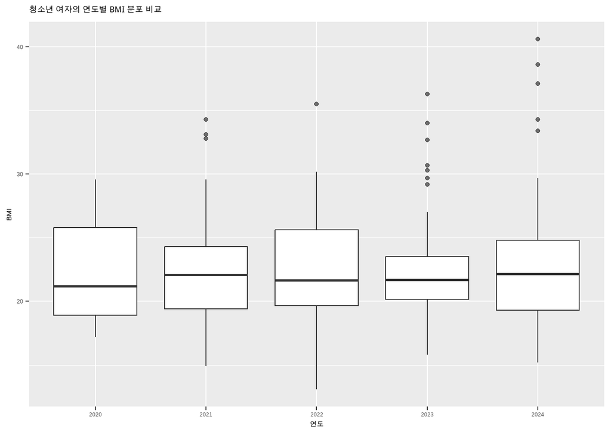

```r
df_bmi_2 <- df_data %>%
  filter( TEST_SEX == "여성" &  AGE_GBN == "청소년") %>%
  select( TEST_YEAR, ITEM_F018) %>%
  rename( bmi = ITEM_F018, year = TEST_YEAR)

ggplot( df_bmi_2, aes(x = year, y = bmi )) +
  geom_boxplot(outlier.alpha = 0.7) +
  labs( title = "청소년 여자의 연도별 BMI 분포 비교",
        x = "연도",
        y = "BMI")
```

이제 남녀 별로 성인의 연도별 BMI 분포를 하나의 그림으로 비교해 보자. 이를 위해 `TEST_SEX` 변수를 `fill` 미적 요소로 지정하여 남녀를 색깔로 구별하여 상자그림을 그릴 수 있다.

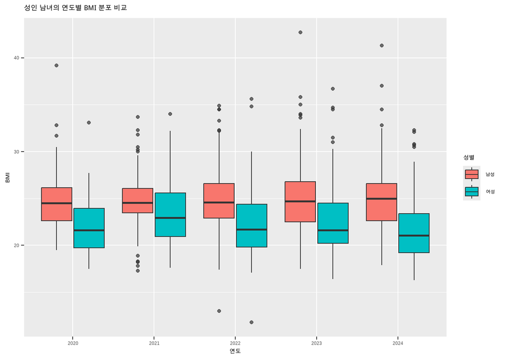

```r
df_bmi_3 <- df_data %>%
  filter( AGE_GBN == "성인") %>%
  select( TEST_YEAR, TEST_SEX, ITEM_F018) %>%
  rename( bmi = ITEM_F018, year = TEST_YEAR, sex = TEST_SEX)

ggplot( df_bmi_3,
        aes(x = year, y = bmi, fill = sex)) +
  geom_boxplot(outlier.alpha = 0.7, position = position_dodge(0.8)) +
  labs( title = "성인 남녀의 연도별 BMI 분포 비교",
        x = "연도",
        y = "BMI",
        fill = "성별")
```

## 리포트 작성 예제

이 절에서는 체력 측정 자료와 등급 기준 자료를 결합하여 청소년에 대하여 근지구력을 측정하는 윗몸말아올리기(`ITEM_F009`)와 반복점프(`ITEM_F010`)의 등급을 산정하여 분포를 구하고 보고서에 사용할 수 있는 표외 그림를 만드는 절차를 설명한다.

**Caution**

국민체력100 청소년 근지구력에 대한 측정 항목은 윗몸말아올리기와 반복점프, 둘 중에 하나만 선택하여 측정한다. 따라서 한 사람에 대하여 두 변수 중 하나의 값은 결측값이다.

### 데이터 준비

```r
df_report_wide <- df_data %>%
  filter( AGE_GBN == "청소년") %>%
  select( MEMB_SEQ, TEST_YEAR, TEST_SEX, TEST_AGE, ITEM_F009, ITEM_F010) %>%
  filter( !(is.na(ITEM_F009) & is.na(ITEM_F010)) )

head(df_report_wide, 20) %>%
  flextable() %>%
  autofit()
```

| MEMB_SEQ | TEST_YEAR | TEST_SEX | TEST_AGE | ITEM_F009 | ITEM_F010 |
| --- | --- | --- | --- | --- | --- |
| 2 | 2023 | 여성 | 17 |  | 15 |
| 5 | 2024 | 여성 | 17 | 21 |  |
| 6 | 2022 | 남성 | 15 |  | 43 |
| 10 | 2021 | 남성 | 17 | 23 |  |
| 11 | 2022 | 남성 | 16 | 46 |  |
| 12 | 2022 | 남성 | 16 |  | 53 |
| 15 | 2020 | 남성 | 17 | 22 |  |
| 17 | 2021 | 남성 | 13 |  | 49 |
| 27 | 2024 | 남성 | 15 |  | 44 |
| 28 | 2024 | 여성 | 17 | 8 |  |
| 29 | 2021 | 남성 | 15 |  | 53 |
| 33 | 2021 | 여성 | 18 |  | 33 |
| 37 | 2021 | 남성 | 15 |  | 48 |
| 42 | 2022 | 남성 | 13 | 18 |  |
| 43 | 2022 | 여성 | 15 | 33 |  |
| 45 | 2024 | 남성 | 18 | 31 |  |
| 47 | 2021 | 남성 | 13 |  | 28 |
| 50 | 2023 | 남성 | 14 |  | 50 |
| 54 | 2023 | 남성 | 15 | 51 |  |
| 55 | 2022 | 남성 | 15 | 20 |  |

다음으로 등급 기준 자료 `df_class_level` 와 결합하려면 앞에서 만든 데이터프레임 `df_report_wide` 를 긴 형식위 자료로 만들어여 한다.

두 측정항목 중 하나만 선택하므로 측정값이 결측이면 자료에서 제외한다.

```r
df_report_long <- df_report_wide %>%
  pivot_longer(
    cols = starts_with("ITEM"),
    names_to = "varname_eng",
    values_to = "value"
  ) %>%
  filter( !is.na(value))

head(df_report_long, 20) %>%
  flextable() %>%
  autofit()
```

| MEMB_SEQ | TEST_YEAR | TEST_SEX | TEST_AGE | varname_eng | value |
| --- | --- | --- | --- | --- | --- |
| 2 | 2023 | 여성 | 17 | ITEM_F010 | 15 |
| 5 | 2024 | 여성 | 17 | ITEM_F009 | 21 |
| 6 | 2022 | 남성 | 15 | ITEM_F010 | 43 |
| 10 | 2021 | 남성 | 17 | ITEM_F009 | 23 |
| 11 | 2022 | 남성 | 16 | ITEM_F009 | 46 |
| 12 | 2022 | 남성 | 16 | ITEM_F010 | 53 |
| 15 | 2020 | 남성 | 17 | ITEM_F009 | 22 |
| 17 | 2021 | 남성 | 13 | ITEM_F010 | 49 |
| 27 | 2024 | 남성 | 15 | ITEM_F010 | 44 |
| 28 | 2024 | 여성 | 17 | ITEM_F009 | 8 |
| 29 | 2021 | 남성 | 15 | ITEM_F010 | 53 |
| 33 | 2021 | 여성 | 18 | ITEM_F010 | 33 |
| 37 | 2021 | 남성 | 15 | ITEM_F010 | 48 |
| 42 | 2022 | 남성 | 13 | ITEM_F009 | 18 |
| 43 | 2022 | 여성 | 15 | ITEM_F009 | 33 |
| 45 | 2024 | 남성 | 18 | ITEM_F009 | 31 |
| 47 | 2021 | 남성 | 13 | ITEM_F010 | 28 |
| 50 | 2023 | 남성 | 14 | ITEM_F010 | 50 |
| 54 | 2023 | 남성 | 15 | ITEM_F009 | 51 |
| 55 | 2022 | 남성 | 15 | ITEM_F009 | 20 |

다음으로 등급 기준 자료 `df_class_level` 를 결합에 사용하기 위하여 다음과 같이 재코딩하여 변수 형식을 변환 한다.

```r
df_class_level_ext <- df_class_level %>%
  rename(TEST_SEX = sex, TEST_AGE = age) %>%
  mutate( TEST_SEX = case_when(
      TEST_SEX == 1 ~ "남성",
      TEST_SEX == 2 ~ "여성")) %>%
  mutate(TEST_SEX = factor(TEST_SEX, levels = c("남성", "여성"))) %>%
  select(TEST_SEX, TEST_AGE, varname_eng,Q30, Q50, Q70)

head(df_class_level_ext, 20) %>%
  flextable() %>%
  autofit()
```

| TEST_SEX | TEST_AGE | varname_eng | Q30 | Q50 | Q70 |
| --- | --- | --- | --- | --- | --- |
| 남성 | 13 | ITEM_F009 | 36 | 49 | 61 |
| 남성 | 14 | ITEM_F009 | 37 | 48 | 60 |
| 남성 | 15 | ITEM_F009 | 29 | 39 | 49 |
| 남성 | 16 | ITEM_F009 | 27 | 38 | 49 |
| 남성 | 17 | ITEM_F009 | 25 | 36 | 46 |
| 남성 | 18 | ITEM_F009 | 29 | 41 | 53 |
| 여성 | 13 | ITEM_F009 | 25 | 37 | 48 |
| 여성 | 14 | ITEM_F009 | 24 | 36 | 47 |
| 여성 | 15 | ITEM_F009 | 23 | 36 | 48 |
| 여성 | 16 | ITEM_F009 | 19 | 30 | 41 |
| 여성 | 17 | ITEM_F009 | 18 | 29 | 41 |
| 여성 | 18 | ITEM_F009 | 16 | 29 | 41 |
| 남성 | 13 | ITEM_F010 | 33 | 39 | 44 |
| 남성 | 14 | ITEM_F010 | 36 | 42 | 48 |
| 남성 | 15 | ITEM_F010 | 38 | 44 | 50 |
| 남성 | 16 | ITEM_F010 | 39 | 45 | 50 |
| 남성 | 17 | ITEM_F010 | 38 | 44 | 50 |
| 남성 | 18 | ITEM_F010 | 40 | 46 | 52 |
| 여성 | 13 | ITEM_F010 | 22 | 27 | 31 |
| 여성 | 14 | ITEM_F010 | 23 | 28 | 34 |

### 자료의 결합

이제 측정자료를 포함한 데이터프레임 `df_report_long` 을 기준으로 등급 기준이 포함된 데이터프레임 `df_class_level_ext` 을 성별, 연령별, 측정항목별로 결합하자.

```r
df_report_merged <- df_report_long %>%
  left_join( df_class_level_ext,
    by = c("TEST_SEX", "TEST_AGE", "varname_eng"))

head(df_report_merged, 20) %>%
  flextable() %>%
  autofit()
```

| MEMB_SEQ | TEST_YEAR | TEST_SEX | TEST_AGE | varname_eng | value | Q30 | Q50 | Q70 |
| --- | --- | --- | --- | --- | --- | --- | --- | --- |
| 2 | 2023 | 여성 | 17 | ITEM_F010 | 15 | 21 | 27 | 33 |
| 5 | 2024 | 여성 | 17 | ITEM_F009 | 21 | 18 | 29 | 41 |
| 6 | 2022 | 남성 | 15 | ITEM_F010 | 43 | 38 | 44 | 50 |
| 10 | 2021 | 남성 | 17 | ITEM_F009 | 23 | 25 | 36 | 46 |
| 11 | 2022 | 남성 | 16 | ITEM_F009 | 46 | 27 | 38 | 49 |
| 12 | 2022 | 남성 | 16 | ITEM_F010 | 53 | 39 | 45 | 50 |
| 15 | 2020 | 남성 | 17 | ITEM_F009 | 22 | 25 | 36 | 46 |
| 17 | 2021 | 남성 | 13 | ITEM_F010 | 49 | 33 | 39 | 44 |
| 27 | 2024 | 남성 | 15 | ITEM_F010 | 44 | 38 | 44 | 50 |
| 28 | 2024 | 여성 | 17 | ITEM_F009 | 8 | 18 | 29 | 41 |
| 29 | 2021 | 남성 | 15 | ITEM_F010 | 53 | 38 | 44 | 50 |
| 33 | 2021 | 여성 | 18 | ITEM_F010 | 33 | 23 | 29 | 36 |
| 37 | 2021 | 남성 | 15 | ITEM_F010 | 48 | 38 | 44 | 50 |
| 42 | 2022 | 남성 | 13 | ITEM_F009 | 18 | 36 | 49 | 61 |
| 43 | 2022 | 여성 | 15 | ITEM_F009 | 33 | 23 | 36 | 48 |
| 45 | 2024 | 남성 | 18 | ITEM_F009 | 31 | 29 | 41 | 53 |
| 47 | 2021 | 남성 | 13 | ITEM_F010 | 28 | 33 | 39 | 44 |
| 50 | 2023 | 남성 | 14 | ITEM_F010 | 50 | 36 | 42 | 48 |
| 54 | 2023 | 남성 | 15 | ITEM_F009 | 51 | 29 | 39 | 49 |
| 55 | 2022 | 남성 | 15 | ITEM_F009 | 20 | 29 | 39 | 49 |

### 등급의 산정

```r
df_report_class <- df_report_merged %>%
  mutate( class = case_when( value < Q30 ~ "4등급",
                             value >= Q30 & value < Q50 ~ "3등급",
                             value >= Q50 & value < Q70 ~ "2등급",
                             value >= Q70 ~ "1등급")) %>%
  mutate( class = factor(class, levels = c("1등급", "2등급", "3등급", "4등급"))) %>%
  select( MEMB_SEQ, TEST_YEAR, TEST_SEX, TEST_AGE, class)

head(df_report_class, 20) %>%
  flextable() %>%
  autofit()
```

| MEMB_SEQ | TEST_YEAR | TEST_SEX | TEST_AGE | class |
| --- | --- | --- | --- | --- |
| 2 | 2023 | 여성 | 17 | 4등급 |
| 5 | 2024 | 여성 | 17 | 3등급 |
| 6 | 2022 | 남성 | 15 | 3등급 |
| 10 | 2021 | 남성 | 17 | 4등급 |
| 11 | 2022 | 남성 | 16 | 2등급 |
| 12 | 2022 | 남성 | 16 | 1등급 |
| 15 | 2020 | 남성 | 17 | 4등급 |
| 17 | 2021 | 남성 | 13 | 1등급 |
| 27 | 2024 | 남성 | 15 | 2등급 |
| 28 | 2024 | 여성 | 17 | 4등급 |
| 29 | 2021 | 남성 | 15 | 1등급 |
| 33 | 2021 | 여성 | 18 | 2등급 |
| 37 | 2021 | 남성 | 15 | 2등급 |
| 42 | 2022 | 남성 | 13 | 4등급 |
| 43 | 2022 | 여성 | 15 | 3등급 |
| 45 | 2024 | 남성 | 18 | 3등급 |
| 47 | 2021 | 남성 | 13 | 4등급 |
| 50 | 2023 | 남성 | 14 | 1등급 |
| 54 | 2023 | 남성 | 15 | 1등급 |
| 55 | 2022 | 남성 | 15 | 4등급 |

### 등급 분포

이제 연도별로 근지구력에 대한 등급의 분포를 구해보자. 아래 코드에서 함수 `count` 는 주어진 두 개의 변수 `TEST_YEAR` 와 `class` 의 조합별로 해당하는 사람의 개수를 `freq` 으로 저장하는 데이터프레임을 만들어 준다.

```r
table_class_1 <- df_report_class %>%
  count(TEST_YEAR, class, name = "freq")

table_class_1 %>%
  flextable() %>%
  autofit()
```

| TEST_YEAR | class | freq |
| --- | --- | --- |
| 2020 | 1등급 | 21 |
| 2020 | 2등급 | 9 |
| 2020 | 3등급 | 5 |
| 2020 | 4등급 | 8 |
| 2021 | 1등급 | 65 |
| 2021 | 2등급 | 27 |
| 2021 | 3등급 | 24 |
| 2021 | 4등급 | 50 |
| 2022 | 1등급 | 74 |
| 2022 | 2등급 | 42 |
| 2022 | 3등급 | 42 |
| 2022 | 4등급 | 64 |
| 2023 | 1등급 | 60 |
| 2023 | 2등급 | 34 |
| 2023 | 3등급 | 39 |
| 2023 | 4등급 | 57 |
| 2024 | 1등급 | 83 |
| 2024 | 2등급 | 33 |
| 2024 | 3등급 | 39 |
| 2024 | 4등급 | 53 |

다음으로 자료에 연도별로각 등급의 비율을 추가해 보자. 이를 위해 `group_by` 와 `mutate` 함수를 이용하여 연도별로 각 등급의 개수를 전체 인원수로 나누어 비율을 계산한다.

```r
table_class_2 <- table_class_1 %>%
  group_by(TEST_YEAR) %>%
  mutate( percent = freq / sum(freq) * 100 ) %>%
  ungroup()

table_class_2 %>%
  flextable() %>%
  autofit()
```

| TEST_YEAR | class | freq | percent |
| --- | --- | --- | --- |
| 2020 | 1등급 | 21 | 48.83721 |
| 2020 | 2등급 | 9 | 20.93023 |
| 2020 | 3등급 | 5 | 11.62791 |
| 2020 | 4등급 | 8 | 18.60465 |
| 2021 | 1등급 | 65 | 39.15663 |
| 2021 | 2등급 | 27 | 16.26506 |
| 2021 | 3등급 | 24 | 14.45783 |
| 2021 | 4등급 | 50 | 30.12048 |
| 2022 | 1등급 | 74 | 33.33333 |
| 2022 | 2등급 | 42 | 18.91892 |
| 2022 | 3등급 | 42 | 18.91892 |
| 2022 | 4등급 | 64 | 28.82883 |
| 2023 | 1등급 | 60 | 31.57895 |
| 2023 | 2등급 | 34 | 17.89474 |
| 2023 | 3등급 | 39 | 20.52632 |
| 2023 | 4등급 | 57 | 30.00000 |
| 2024 | 1등급 | 83 | 39.90385 |
| 2024 | 2등급 | 33 | 15.86538 |
| 2024 | 3등급 | 39 | 18.75000 |
| 2024 | 4등급 | 53 | 25.48077 |

마지막으로 보기 쉽도록 컬럼명을 한글로 바꾸어 보자. 또한 비율은 소수점 2자리까지 표현하자.

```r
table_class_2 <- table_class_2 %>%
  mutate( percent = round(percent, 2)) %>%
  rename( 년도 = TEST_YEAR, 등급 = class, 도수 = freq, 비율 = percent)

table_class_2 %>%
  flextable() %>%
  autofit()
```

| 년도 | 등급 | 도수 | 비율 |
| --- | --- | --- | --- |
| 2020 | 1등급 | 21 | 48.84 |
| 2020 | 2등급 | 9 | 20.93 |
| 2020 | 3등급 | 5 | 11.63 |
| 2020 | 4등급 | 8 | 18.60 |
| 2021 | 1등급 | 65 | 39.16 |
| 2021 | 2등급 | 27 | 16.27 |
| 2021 | 3등급 | 24 | 14.46 |
| 2021 | 4등급 | 50 | 30.12 |
| 2022 | 1등급 | 74 | 33.33 |
| 2022 | 2등급 | 42 | 18.92 |
| 2022 | 3등급 | 42 | 18.92 |
| 2022 | 4등급 | 64 | 28.83 |
| 2023 | 1등급 | 60 | 31.58 |
| 2023 | 2등급 | 34 | 17.89 |
| 2023 | 3등급 | 39 | 20.53 |
| 2023 | 4등급 | 57 | 30.00 |
| 2024 | 1등급 | 83 | 39.90 |
| 2024 | 2등급 | 33 | 15.87 |
| 2024 | 3등급 | 39 | 18.75 |
| 2024 | 4등급 | 53 | 25.48 |

### 분포표 작성

이제 위에서 구한 등급의 분포를 등급이 변수명이 되는 넓은 형식의 자료로 만들어 보자. 또한 각 년도에 해당하는 총 인원도 계산에서 표에 포함한다.

```r
table_class_3 <- table_class_2 %>%
  pivot_wider(
    names_from = 등급,
    values_from = c(도수, 비율),
    names_glue = "{.value}_{등급}"
  ) %>%
  mutate(총인원 = rowSums(across(contains("도수")), na.rm = TRUE)) %>%
  relocate( 총인원, .after = 년도)

table_class_3 %>%
  flextable() %>%
  autofit()
```

| 년도 | 총인원 | 도수_1등급 | 도수_2등급 | 도수_3등급 | 도수_4등급 | 비율_1등급 | 비율_2등급 | 비율_3등급 | 비율_4등급 |
| --- | --- | --- | --- | --- | --- | --- | --- | --- | --- |
| 2020 | 43 | 21 | 9 | 5 | 8 | 48.84 | 20.93 | 11.63 | 18.60 |
| 2021 | 166 | 65 | 27 | 24 | 50 | 39.16 | 16.27 | 14.46 | 30.12 |
| 2022 | 222 | 74 | 42 | 42 | 64 | 33.33 | 18.92 | 18.92 | 28.83 |
| 2023 | 190 | 60 | 34 | 39 | 57 | 31.58 | 17.89 | 20.53 | 30.00 |
| 2024 | 208 | 83 | 33 | 39 | 53 | 39.90 | 15.87 | 18.75 | 25.48 |

**`flextable` 의 `separate_header`**

`flextable` 패키지의 `separate_header` 함수는 언더바(`_`)로 연결된 컬럼명을 분리하여 계층적 컬럼명을 만들 수 있는 기능이 있다.

```r
table_class_3 %>%
  flextable() %>%
  separate_header() %>%
  autofit()
```

| 년도 | 총인원 | 도수 1등급 | 도수 2등급 | 도수 3등급 | 도수 4등급 | 비율 1등급 | 비율 2등급 | 비율 3등급 | 비율 4등급 |
| --- | --- | --- | --- | --- | --- | --- | --- | --- | --- |
| 2020 | 43 | 21 | 9 | 5 | 8 | 48.84 | 20.93 | 11.63 | 18.60 |
| 2021 | 166 | 65 | 27 | 24 | 50 | 39.16 | 16.27 | 14.46 | 30.12 |
| 2022 | 222 | 74 | 42 | 42 | 64 | 33.33 | 18.92 | 18.92 | 28.83 |
| 2023 | 190 | 60 | 34 | 39 | 57 | 31.58 | 17.89 | 20.53 | 30.00 |
| 2024 | 208 | 83 | 33 | 39 | 53 | 39.90 | 15.87 | 18.75 | 25.48 |

### 분포 그림 작성

이제 연도별로 각 등급의 비율을 비교할 수 있는 누적 막대그래프를 그려보자. 이를 위해 `ggplot` 함수를 이용하여 막대그래프를 그린다. 이 경우 긴 형식의 자료를 이용해야 한다.

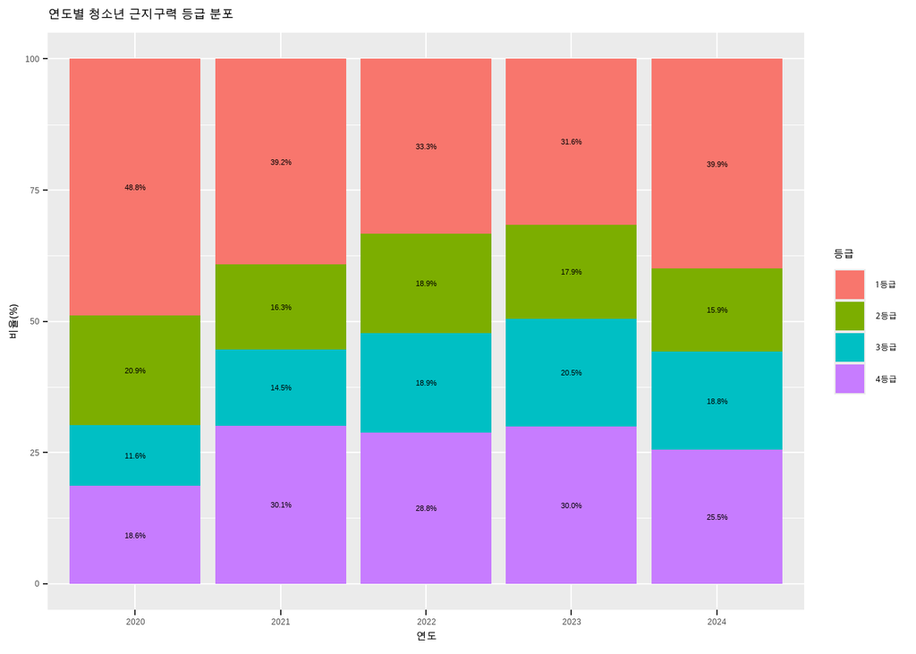

```r
ggplot(table_class_2, aes(x = 년도, y = 비율, fill = 등급)) +
  geom_bar(stat = "identity") +
  geom_text(
    aes(label = sprintf("%.1f%%", 비율)),
    position = position_stack(vjust = 0.5),
    size = 3
  ) +
  labs(title = "연도별 청소년 근지구력 등급 분포",
    x = "연도", y = "비율(%)", fill = "등급")
```

### `quarto` 의 리포트 작성

이제 위에서 작성한 표와 그림을 `quarto` 리포트에 포함하여 최종 보고서를 HTML 또는 MS WORD 형식으로 출력할 수 있다. `quarto` 문서(확장자가 `qmd` 인 화일)에서 가장 처음에 다음과 같은 YML 해더를 포함시키면 HTML 또는 MS WORD 형식으로 결과를 저장한다.

아래 YML 형식의 명령문에서 `reference-doc` 는 MS WORD 형식으로 결과를 저장할 때 style reference 를 사용할 화일 이름이다([다음 사이트 참조](https://quarto.org/docs/output-formats/ms-word-templates.html#:~:text=Word%20Templates-,Using%20Templates,Applying%20Custom%20Styles)).

```
---
title: "국민체력 100 자료를 이용한 데이터 분석 예제"
author: "서울시립대학교 빅데이터 혁신융합대학 사업단"
date: "today"

format:
  html:
    toc: true
    embed-resources: true
  docx:
    toc: true
    toc-depth: 2
    number-sections: true
    reference-doc: custom-reference-doc-landscape.docx
---
```